# envs193ds_hw3

Hibah Ganie

2025-05-28

## [Hibah’s Github Repository](https://github.com/hibdawg/ENVS-193DS_homework-03)

```r
library(tidyverse) # General Use
library(janitor) # Cleaning data Frames
library(dplyr) # Mutate columns
library(lubridate) # make dealing with dates easier
library(here) # File Organization
```

```r
library(readxl) # reading .xlsx files
library(ggeffects) # generating model predictions
library(gtsummary) # generating summary tables for models
library(ggplot2) # visualizations
library(hms) # working with times
library(readr) # Reads in Data
library(xfun)
library(gt) # tables
library(png) # images
library(grid) # images
library(ggimage) # images

my_data <- read_csv(here("data", "hibdata2.csv")) # read in my data
clean_hibdata <- my_data |> # select my data frame to clean
  clean_names() |> # clean up names, remove spaces etc
  rename(
    exam_week = finals_week, # rename the columns to be easier to read
    shared = shared_table,
    floor = floor_level,
    day = dayw) |>
   mutate( # create a new colum to define category of study sessions
    duration = as_hms(duration),
    duration_seconds = as.numeric(duration),
    duration_category = if_else(duration_seconds < 4500, "short", "long"), # adding a new categorical column to organize the length of study sessions can give insight into how the behavior of library visits changes over time
    duration_category = as.factor(duration_category), # change all the columns from characters to factors
    outlet = as.factor(outlet),
    shared = as.factor(shared),
    floor = as.factor(floor),
    exam_week = as.factor(exam_week),
    week = factor(week, # make an ordered factor for each week
                  ordered = TRUE,
                  levels = c("1", "2","3", "4", "5", "6", "7", "8", "9", "10")
    ),
    day = factor(day,
                 ordered = TRUE, # make each day of the week a ordered factor
                 levels = c("Monday", "Tuesday", "Wednesday", "Thursday", "Friday", "Saturday", "Sunday")
                 )
  ) |>
  select(time, scouting, exam_week, week, outlet, shared, duration, floor, day, duration_category) # select which columns to choose
```

## Part 2. Problems

## Problem 1. Personal Data

# Data Summarizing

#A.  
[I could compare how the duration of events follows my class schedule and see how I have shorter events on days where I have class due to gaps in my schedule where I study. I also want to compare how total study time based on weeks increase, or may taper off as I struggle to find a spot in the library and may need to go elsewhere to study.]

#B.

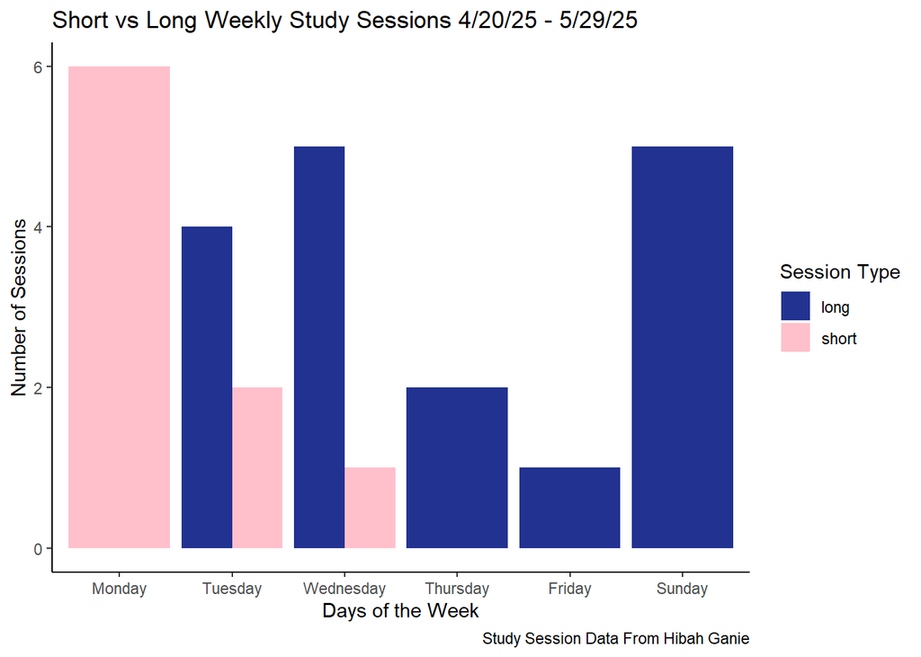

```r
ggplot(
  clean_hibdata, # Select Clean Datafram
  aes(x = day, # X axis
      fill = duration_category) # based on Category of Session Length
) +
  geom_bar(position = "dodge") + # Bar Graph
  labs( # Add labels
    title = "Short vs Long Weekly Study Sessions 4/20/25 - 5/29/25", # title of Graph
    x = "Days of the Week", # X Label
    y = "Number of Sessions", # Y Lael
    fill = "Session Type", # Differentiate Based on category
    caption = "Study Session Data From Hibah Ganie"
  ) +
  theme_classic() + # choose theme!
  scale_fill_manual( # manually change colors
    values = c("short" = "pink", # pink
               "long" = "#223291")) # orange
```

#D.

```r
hibtable <- clean_hibdata |>  # making a table with my cleaned data
  select(day, duration_category) |> #select which columns i want in my table
  tbl_summary( # choose how I want the data to be divided up in, as categorical: short and long
    by = day,
    statistic = all_categorical() ~ "{n}",
    label = list(duration_category ~ "Session Type")
  ) |>
  bold_labels() # add a pop of boldness in my chaer

hibtable_gt <- hibtable |> # to add color i need to convert to gt table.,,,
  as_gt() |>
  tab_header(
    title = md("**Weekly Study Session Count by Day and Type**") # new header!!
  ) |>
  tab_style(
    style = cell_text(color = "white", weight = "bold"), # add color and bold!!
    locations = cells_title(groups = "title")
  ) |>
  tab_options(
    heading.background.color = "darkslateblue" # color!!
  )

hibtable_gt
```

**Weekly Study Session Count by Day and Type**

| **Characteristic** | **Monday** N = 6<sup>1</sup> | **Tuesday** N = 6<sup>1</sup> | **Wednesday** N = 6<sup>1</sup> | **Thursday** N = 2<sup>1</sup> | **Friday** N = 1<sup>1</sup> | **Saturday** N = 0<sup>1</sup> | **Sunday** N = 5<sup>1</sup> |
| --- | --- | --- | --- | --- | --- | --- | --- |
| Session Type |  |  |  |  |  |  |  |
| long | 0 | 4 | 5 | 2 | 1 | 0 | 5 |
| short | 6 | 2 | 1 | 0 | 0 | 0 | 0 |

<sup>1</sup> n

## Problem 2: Affective Visualization

#A. [I really enjoyed the simplicity and amount of information able to be conveyed in the interface between graph lines and nature. Since my study sessions are characterized by many different aspects, I would like to do a similar concept. I want to show how the intensity of studying changes throughout the week based on my workload.]

#B.

[figure not shown]

#C [

[figure not shown]

]

#D [I am showing how the duration and frequency of my study sessions changes throughout the week. The interface between graph and image was highly influenced by Jill Peltos paintings which include the slope of graphs in landscapes I did an online drawing on a drawing app. While the online format may be easier, in my next draft I would like to use a physical medium]

## 3 Statistical Critique

#a. [A one-way analysis of variance (ANOVA), was used to look at differences between vegetation and watershed regions. The response variables are CAR, SAR, C density, organic and mineral sedimentation, with the predictor being watershed regions.]

[figure not shown]

#b. [The X-axis and plot itself is a bit clogged with codes, such as: CA,CT,BCD, etc, which reduce the readability of the figure. However the graph is very readable and clearly represents that standard error, mean value, and interquartile range for each figure. The figure shows summary statistics. We can see some of the underlying data in the form of raw data points.]

#C. [Considering how many sites the author had to include, the design is decently uncluttered, however the codes clutter the plot due to the sheer amount. The data to ink ratio is high, as each element explains essiental information.]

#D. [I thik integrating a color coding system would help alieviate some of the cluttering in the plot. They could possibly give each plot a different color/symbol and maybe put the legend outside of the plot. They could also streamline the means, as the diamonds overlap the essiential information, such as means and get lost. It could also help to group by region to declutter the plot.]

##Note: # I am not sure why my images will not load in, as when I add the code to the path I am able to click on the code and open the image manually.